# Beyond The Headlines: Exploring Insights From Stocks

#### Group 19 (Stockbusters): Brigid Sax, Delvin Eluvathingal, Nan Liu, Navneeth Oruganti, Rakshanda Hedawoo, Saketh Gangavaram, Sumedh Tirodkar

## **Introduction and Summary:**

The COVID-19 pandemic is a one off global event. It has sent shockwaves to economies across the globe. Similarly, other global crises have affected the market in ways that were previously unforeseen. In this project, we aim to perform an in-depth analysis of the impact of the COVID-19 pandemic, as well as global crises such as the Ukraine War, on the performance of the top 5 stocks within four sectors that were severely affected by the crisis. The four sectors we are focusing on are Tech, Pharma, Telecom and FMCG (Fast moving consumer goods) and only on US stocks for this. This analysis is pivotal in understanding how economic crises impact stock performance and the broader financial markets. The study will be conducted in a Jupyter Notebook environment using statistical models and is expected to span a duration of 40-45 days.

In a more specific sense, creating these analyses may help us provide contextual and researched advice to investors that may want to invest in major stocks, but want to minimize risk. There is no way to accurately predict how stocks will perform, particularly in a crisis, but our analysis can help inform those who plan to invest in these sectors how to handle their investments in the event of any type of crisis that introduces great risk.

In order to analyze stock performance throughout the pandemic and through the Ukraine War, we are pulling stock data from October 2019 to the current date. We will be taking a closer look at these dates listed below in order to hone in on the impacts from these specific events:

1. **Lockdown 1 :- March 2020 to July 2020**
2. **Lockdown 2 (Omicron):- November 2021 to February 2022**
3. **Ukraine War :- 24 February 2022 to till date**

## **Our research endeavors to address the following key questions:**

● What were the variations in the price movements of the top 5 stocks in the Tech, Pharma, Telecom and FMCG sectors most adversely affected by major world events like COVID-19 pandemic and the Ukraine-Russia war?  
● Can we discern the factors acting as headwinds (Negative impact due to the pandemic and the Ukraine war) and tailwinds (positive benefits due to thsee same events) affecting these sectors during the crisis?  
● How is the performance of the top 5 stocks in the Tech, Pharma, Telecom and FMCG sectors related to the overall global economic indicators and trends?  
● How severe is the change that the Tech, Pharma, Telecom and FMCG sectors have gone through, related to one off global events?

We expect to gain valuable insights from our research on how different sectors and individual stocks responded to the impacts of the pandemic and the war. Our analysis aims to reveal patterns that show which sectors and stocks demonstrated resilience in the face of these external shocks and which ones proved vulnerable. Additionally, we will identify potential indicators that could predict how these sectors would react, whether in advance or with a delay. We plan to validate these patterns across various timeframes, depending on the results of our initial exploratory analysis. Ultimately, our findings are intended to offer important insights into how external shocks affect financial markets. These insights will serve as a valuable resource for investors and policymakers, helping them make more informed decisions in response to such events.

##### FMCG: The majority of supermarkets and retail chains were closed during lockdown, which was anticipated to cause a dramatic decline in the share price.

##### PHARMA: By the time COVID was in place, many pharma companies were already working on vaccines. During the second lockdown, vaccine development had advanced, and so this sector will respond the quickest of all the sectors.

##### TECH: It took some time for them to comprehend that the price of digital goods would rise so they didn't hire immediately, but eventually the tech stocks did rise.

##### TELECOM: The lockdown caused these sectors to perform well once 5G was released to the public due to the increased demand for data and high speeds owing to the lockdown.

EDA to be done to infer more insights by digging deeper into our findings from the data.  
We anticipate a potential significant decline in the FMCG (Fast-Moving Consumer Goods) stocks, while pharmaceutical stocks may have experienced an extraordinary surge. We intend to substantiate this hypothesis by analyzing the patterns that emerged during the lockdown period and exploring other prevalent trends both before and after the lockdown.

# Stock Description

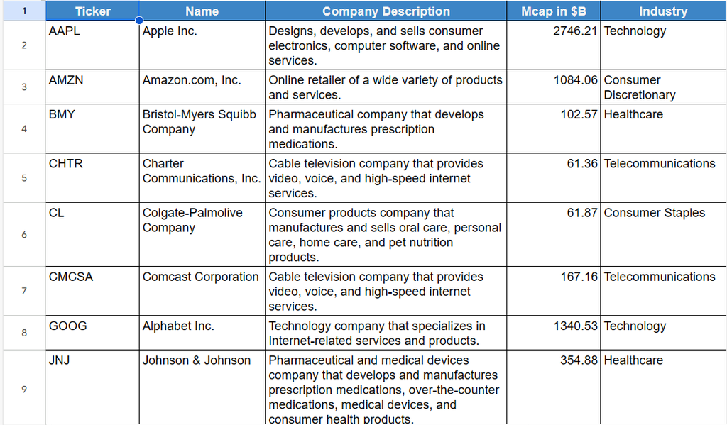

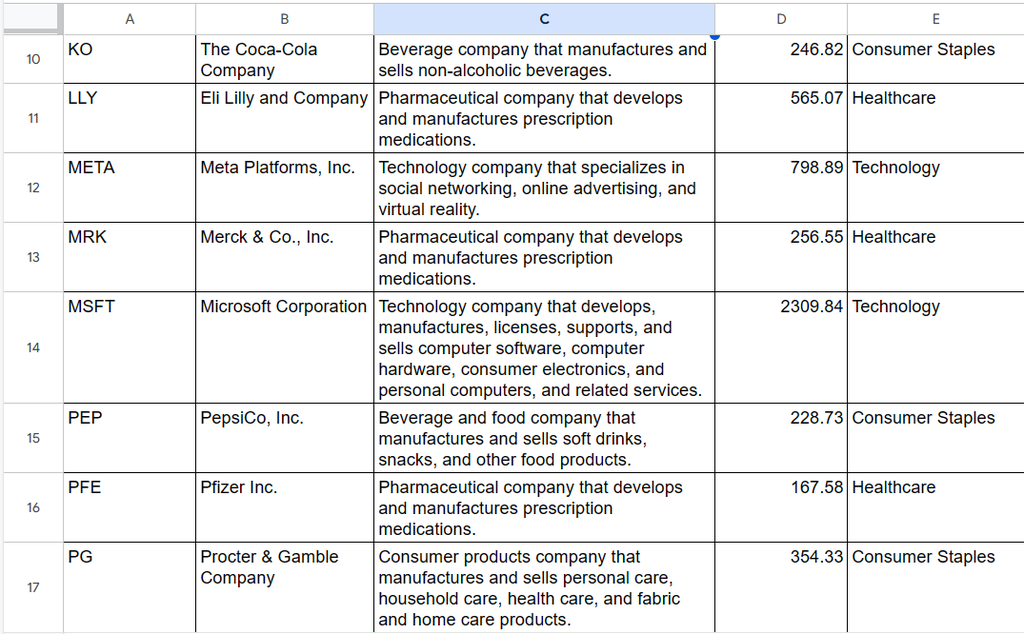

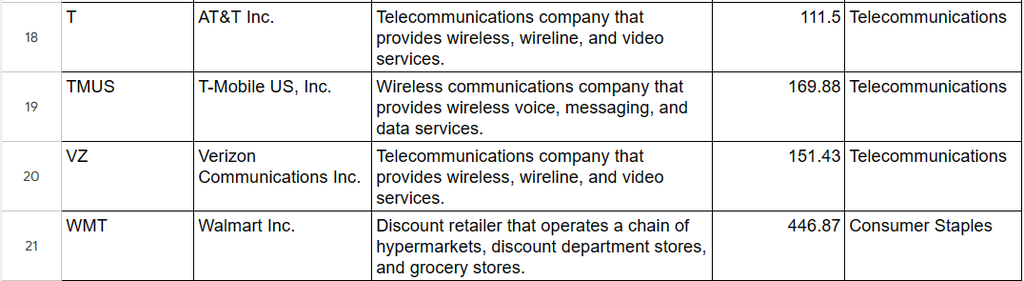

## Milestones and Progress

### Our original milestones from our proposal up until this date include:

#### Data Collection and Preprocessing 10/19 (Completed)

###### ● Data Gathering 10/15

###### ● Figuring out the Libraries required 10/15

###### ● Data Cleaning 10/18

###### ● Data Merging 10/19

#### Data Transformation 10/26 (Completed)

###### ● Index calculation 10/23

###### ● Dataset creation 10/26

#### Data Analysis and Visualization 11/22 (In Progress)

###### ● Analysis 1 - Impact of pandemic on stock prices 10/31 (Completed)

###### ● Creating Visualization for analysis 1 11/01 (Completed)

###### ● Analysis 2 - Factors for Headwinds and Tailwinds 11/07 (Incomplete)

###### ● Creating Visualization for analysis 2 11/08 (Incomplete)

#### Compiling Project Update 11/09 (Completed)

#### Submit Project Update 11/10 (Completed)

### Explanation

Currently, we have not met all of our milestones that we set in our proposal. This is due to the fact that we had a difficult time merging the datasets, as we ended up having to pull index data from a different site than our stock data. Now that we have all of the data, it will be much easier to create our analyses. In order to catch up, we plan to complete our final two visualizations simultaneously, rather than during different spans of time.

In order to complete our next steps, we need to do research on visualizations that are interesting and easy for readers to interpret. Because our topic is so complex, we need to make sure that our presentation of the data is not boring or useless to those who do not understand stock data.

## Data Acquisition and Cleaning Code

So far, we have been able to collect all of our data from Yahoo Finance (stocks) and MarketWatch (global indexes), and merge them together, as well as clean before creating our index values for each stock.  
We first had to concatenate the stock data together, then the indexes before merging both to create a hierarchically indexed dataframe. We cleaned the data by reformatting the date/time index in order to match them up for the merging of the indexes and stocks. In this case, we do not need to replace missing values as they are useful in our analysis and indicate that the stock market was closed on that day.

## What are Indexes?

In the realm of financial analysis, indexing plays a crucial role in harmonizing diverse metrics and facilitating meaningful comparisons. The process involves rescaling data to a common denominator, providing a standardized basis for evaluation. In the described scenario, two indexing methodologies are employed: equal weighted indexing and reindexing. Equal weighted indexing allocates a uniform 20% weight to each of the five stocks within the sector, effectively capturing industry-level effects. On the other hand, reindexing involves adjusting the base values of multiple stocks relative to each other, often setting them all to a common starting point, such as 100. This process allows for the observation of patterns and performance changes within a specified time frame. The equal weighted index offers a straightforward representation of sectoral dynamics by aggregating proportional contributions from each stock, while reindexing introduces a temporal dependency by aligning stock values to a previous time point. Both indexing methods contribute valuable insights for analyzing stock market behavior and sectoral trends over specific time intervals.

```python
# importing Data Analysis & Visualization library
import pandas as pd
import seaborn as sns
import matplotlib.pyplot as plt
```

### Loading the data sets into the Jupyter Notebook

Each individual stock or global index data frame is created with previously downloaded csv files. Since it is a csv file, we separate based on a comma and because we want to look at the change over time, we are using the column 'Date' as our index.

```python
# defining the file path. Change this according to your local system where you have placed your "DataFiles" folder containing the data tables
file_path = ''

#Loading data for all the stocks from the datafiles
dfAAPL = pd.read_csv(file_path + 'AAPL.csv', delimiter = ',', index_col = 'Date')

dfAMZN = pd.read_csv(file_path + 'AMZN.csv', delimiter = ',', index_col = 'Date')

dfBMY = pd.read_csv(file_path + 'BMY.csv', delimiter = ',', index_col = 'Date')

dfCL = pd.read_csv(file_path + 'CL.csv', delimiter = ',', index_col = 'Date')

dfCMCSA = pd.read_csv(file_path + 'CMCSA.csv', delimiter = ',', index_col = 'Date')

dfGOOG = pd.read_csv(file_path + 'GOOG.csv', delimiter = ',', index_col = 'Date')

dfJNJ = pd.read_csv(file_path + 'JNJ.csv', delimiter = ',', index_col = 'Date')

dfKO = pd.read_csv(file_path + 'KO.csv', delimiter = ',', index_col = 'Date')

dfCHTR = pd.read_csv(file_path + 'CHTR.csv', delimiter = ',', index_col = 'Date')

dfLLY = pd.read_csv(file_path + 'LLY.csv', delimiter = ',', index_col = 'Date')

dfMETA = pd.read_csv(file_path + 'META.csv', delimiter = ',', index_col = 'Date')

dfMRK = pd.read_csv(file_path + 'MRK.csv', delimiter = ',', index_col = 'Date')

dfMSFT = pd.read_csv(file_path + 'MSFT.csv', delimiter = ',', index_col = 'Date')

dfPEP = pd.read_csv(file_path + 'PEP.csv', delimiter = ',', index_col = 'Date')

dfPFE = pd.read_csv(file_path + 'PFE.csv', delimiter = ',', index_col = 'Date')

dfPG = pd.read_csv(file_path + 'PG.csv', delimiter = ',', index_col = 'Date')

dfT = pd.read_csv(file_path + 'T.csv', delimiter = ',', index_col = 'Date')

dfTMUS = pd.read_csv(file_path + 'TMUS.csv', delimiter = ',', index_col = 'Date')

dfVZ = pd.read_csv(file_path + 'VZ.csv', delimiter = ',', index_col = 'Date')

dfWMT = pd.read_csv(file_path + 'WMT.csv', delimiter = ',', index_col = 'Date')

df500_19 = pd.read_csv(file_path + 'INDEX_US_S&P US_SPX_Oct19-20.csv', delimiter = ',')

df500_20 = pd.read_csv(file_path + 'INDEX_US_S&P US_SPX_Oct20-21.csv', delimiter = ',')

df500_21 = pd.read_csv(file_path + 'INDEX_US_S&P US_SPX_Oct21-22.csv', delimiter = ',')

df500_22 = pd.read_csv(file_path + 'INDEX_US_S&P US_SPX_Oct22-23.csv', delimiter = ',')

dfDow_19 = pd.read_csv(file_path + 'INDEX_US_DOW JONES GLOBAL_DJIA_Oct19-20.csv', delimiter = ',')

dfDow_20 = pd.read_csv(file_path + 'INDEX_US_DOW JONES GLOBAL_DJIA_Oct20-21.csv', delimiter = ',')

dfDow_21 = pd.read_csv(file_path + 'INDEX_US_DOW JONES GLOBAL_DJIA_Oct21-22.csv', delimiter = ',')

dfDow_22 = pd.read_csv(file_path + 'INDEX_US_DOW JONES GLOBAL_DJIA_Oct22-23.csv', delimiter = ',')
```

## Concatenating Indexes

Because every single dataframe has the same named columns, we need to concatenate these dataframes and use keys in order to hierarchically index the different columns for each stock or index.

For our global index dataframes (S&P 500 and dow Jones), their data came in a format that included commas to indicate the number was in thousands. However, this did not match the data from the stocks, so we replaced each value that had a comma with nothing, and converted the values to floats so we could later do analysis on them.

Again for our global index dataframes, we set the index to be the date, whil for our stocks dataframe, we used an inner join in order to concatenate on the date index for each stock (so there is only one date index).

```python
#Creating s&p500 dataset
df500 = pd.concat([df500_22,df500_21,df500_20,df500_19])
df500.set_index('Date',inplace=True)

df500 = df500.apply(lambda value: value.str.replace(',','').astype(float))
```

```python
#creating Dow dataset
dfDow = pd.concat([dfDow_22,dfDow_21,dfDow_20,dfDow_19])
dfDow.set_index('Date',inplace=True)

dfDow = dfDow.apply(lambda value: value.str.replace(',','').astype(float))
```

```python
#creating merged dataset for all stocks
dfStocks = pd.concat((dfAAPL, dfAMZN, dfBMY, dfCHTR, dfCL, dfCMCSA, dfGOOG, dfJNJ, dfKO, dfLLY, dfMETA, dfMRK, dfMSFT, dfPEP, dfPFE, dfPG, dfT, dfTMUS, dfVZ, dfWMT), join = 'inner', keys = ['AAPL', 'AMZN', 'BMY', 'CHTR', 'CL', 'CMCSA', 'GOOG', 'JNJ', 'KO', 'LLY', 'META', 'MRK', 'MSFT', 'PEP', 'PFE', 'PG', 'T', 'TMUS', 'VZ', 'WMT'], axis = 1)
```

## Merging Dataset

Next, we merged all three datasets. First, we concatenated the two global indexes, once again, so that we could hierarchically index them, regardless of the fact that they have the same column names. We did an inner join on the date index so that there was only one date index.

```python
dfIndexes = pd.concat((df500, dfDow), join ='inner', keys=['S&P500', 'DJIA30'],axis=1)
```

```python
dfIndexes.head()
```

| Date | S&P500 Open | S&P500 High | S&P500 Low | S&P500 Close | DJIA30 Open | DJIA30 High | DJIA30 Low | DJIA30 Close |
| --- | --- | --- | --- | --- | --- | --- | --- | --- |
| 10/24/2023 | 4235.79 | 4259.38 | 4219.43 | 4247.68 | 33089.64 | 33272.19 | 32988.43 | 33141.38 |
| 10/23/2023 | 4210.40 | 4255.84 | 4189.22 | 4217.04 | 32993.02 | 33234.85 | 32892.19 | 32936.41 |
| 10/20/2023 | 4273.85 | 4276.56 | 4223.03 | 4224.16 | 33365.27 | 33425.77 | 33118.12 | 33127.28 |
| 10/19/2023 | 4321.36 | 4339.54 | 4269.69 | 4278.00 | 33669.52 | 33852.39 | 33368.58 | 33414.17 |
| 10/18/2023 | 4357.35 | 4364.20 | 4303.84 | 4314.60 | 33960.25 | 33991.51 | 33598.64 | 33665.08 |

### Change DateTime Format

Before merging the stocks data and the indexes data, we needed to make sure that the datetime format matched up. The global indexes dataframe had a date index in month/day/year format, and we needed to convert this to year-month-date format, in order to make it the same as the stocks index.

```python
dfIndexes.index = dfIndexes.index.map(lambda d: pd.to_datetime(d).strftime('%Y-%m-%d'))
```

### Rounding Values

The values in the index dataframe were rounded to 2 decimal points, so we are doing the same thing to the stocks dataframe in order to help us with our analysis later.

```python
dfStocks = dfStocks.round(2)
dfStocks.head()
```

| Date | AAPL Open | AAPL High | AAPL Low | AAPL Close | AAPL Adj Close | AAPL Volume | AMZN Open | AMZN High | AMZN Low | AMZN Close | ... | VZ Low | VZ Close | VZ Adj Close | VZ Volume | WMT Open | WMT High | WMT Low | WMT Close | WMT Adj Close | WMT Volume |
| --- | --- | --- | --- | --- | --- | --- | --- | --- | --- | --- | --- | --- | --- | --- | --- | --- | --- | --- | --- | --- | --- |
| 2019-10-24 | 61.13 | 61.20 | 60.45 | 60.90 | 59.23 | 69275200 | 88.55 | 89.42 | 88.01 | 89.04 | ... | 60.41 | 60.58 | 49.04 | 11143800 | 119.15 | 119.57 | 118.51 | 119.10 | 111.73 | 2900300 |
| 2019-10-25 | 60.79 | 61.68 | 60.72 | 61.64 | 59.96 | 73477200 | 84.88 | 88.21 | 84.75 | 88.07 | ... | 59.21 | 60.37 | 48.87 | 15036400 | 119.00 | 119.33 | 118.20 | 119.04 | 111.68 | 2564300 |
| 2019-10-28 | 61.86 | 62.31 | 61.68 | 62.26 | 60.56 | 96572800 | 87.40 | 88.93 | 87.12 | 88.85 | ... | 60.04 | 60.18 | 48.72 | 14621400 | 119.25 | 119.70 | 118.53 | 119.22 | 111.85 | 3404600 |
| 2019-10-29 | 62.24 | 62.44 | 60.64 | 60.82 | 59.16 | 142839600 | 88.74 | 88.85 | 87.79 | 88.14 | ... | 60.07 | 60.19 | 48.73 | 10619900 | 118.50 | 118.73 | 117.08 | 117.15 | 109.91 | 4791100 |
| 2019-10-30 | 61.19 | 61.33 | 60.30 | 60.81 | 59.15 | 124522000 | 88.01 | 89.12 | 87.96 | 89.00 | ... | 60.41 | 60.82 | 49.24 | 12136500 | 117.18 | 118.37 | 117.05 | 118.10 | 110.80 | 2996200 |

5 rows × 120 columns

### Final Merge!

Finally, we merged the stocks dataframe and the global indexes dataframe on their, now the same, date index. The dataset is hierarchically indexed and we can see each column for each stock or index.

```python
dataset = dfStocks.join(dfIndexes)
dataset = pd.merge(dfStocks, dfIndexes, on = 'Date', how ='inner')
```

```python
dataset.head()
```

| Date | AAPL Open | AAPL High | AAPL Low | AAPL Close | AAPL Adj Close | AAPL Volume | AMZN Open | AMZN High | AMZN Low | AMZN Close | ... | WMT Adj Close | WMT Volume | S&P500 Open | S&P500 High | S&P500 Low | S&P500 Close | DJIA30 Open | DJIA30 High | DJIA30 Low | DJIA30 Close |
| --- | --- | --- | --- | --- | --- | --- | --- | --- | --- | --- | --- | --- | --- | --- | --- | --- | --- | --- | --- | --- | --- |
| 2019-10-24 | 61.13 | 61.20 | 60.45 | 60.90 | 59.23 | 69275200 | 88.55 | 89.42 | 88.01 | 89.04 | ... | 111.73 | 2900300 | 3014.78 | 3016.07 | 3000.42 | 3010.29 | 26893.93 | 26931.78 | 26714.34 | 26805.53 |
| 2019-10-25 | 60.79 | 61.68 | 60.72 | 61.64 | 59.96 | 73477200 | 84.88 | 88.21 | 84.75 | 88.07 | ... | 111.68 | 2564300 | 3003.32 | 3027.39 | 3001.94 | 3022.55 | 26789.61 | 27015.37 | 26765.68 | 26958.06 |
| 2019-10-28 | 61.86 | 62.31 | 61.68 | 62.26 | 60.56 | 96572800 | 87.40 | 88.93 | 87.12 | 88.85 | ... | 111.85 | 3404600 | 3032.12 | 3044.08 | 3032.12 | 3039.42 | 27040.33 | 27167.88 | 27028.71 | 27090.72 |
| 2019-10-29 | 62.24 | 62.44 | 60.64 | 60.82 | 59.16 | 142839600 | 88.74 | 88.85 | 87.79 | 88.14 | ... | 109.91 | 4791100 | 3035.39 | 3047.87 | 3034.81 | 3036.89 | 27061.07 | 27165.94 | 27039.76 | 27071.42 |
| 2019-10-30 | 61.19 | 61.33 | 60.30 | 60.81 | 59.15 | 124522000 | 88.01 | 89.12 | 87.96 | 89.00 | ... | 110.80 | 2996200 | 3039.74 | 3050.10 | 3025.96 | 3046.77 | 27110.71 | 27204.36 | 26999.64 | 27186.69 |

5 rows × 128 columns

# Data Processing

## Calculating relative indexes of each sector

```python
def get_stock_index(df,stock_name):
    if stock_name == 'Tech':
        tech_stock_df = pd.concat((df.AAPL.Close,df.AMZN.Close,df.GOOG.Close,df.META.Close,df.MSFT.Close),join = 'inner',keys=['AAPL','AMZN','GOOG','META','MSFT'],axis=1)
        tech_stock_df['TechIndex'] = 0.2*tech_stock_df.AAPL+0.2*tech_stock_df.AMZN+0.2*tech_stock_df.GOOG+0.2*tech_stock_df.META+0.2*tech_stock_df.MSFT
        return tech_stock_df
    elif stock_name == 'Pharma':
        pharma_stock_df = pd.concat((df.JNJ.Close,df.PFE.Close,df.MRK.Close,df.BMY.Close,df.LLY.Close),join = 'inner',keys=['JNJ','PFE','MRK','BMY','LLY'],axis=1)
        pharma_stock_df['PharmaIndex'] = 0.2*pharma_stock_df.JNJ+0.2*pharma_stock_df.PFE+0.2*pharma_stock_df.MRK+0.2*pharma_stock_df.BMY+0.2*pharma_stock_df.LLY
        return pharma_stock_df
    elif stock_name == 'Telecom':
        telecom_stock_df = pd.concat((df['T'].Close,df.VZ.Close,df.TMUS.Close,df.CMCSA.Close,df.CHTR.Close),join = 'inner',keys=['T','VZ','TMUS','CMCSA','CHTR'],axis=1)
        telecom_stock_df['TelecomIndex'] = 0.2*telecom_stock_df['T']+0.2*telecom_stock_df.VZ+0.2*telecom_stock_df.TMUS+0.2*telecom_stock_df.CMCSA+0.2*telecom_stock_df.CHTR
        return telecom_stock_df
    elif stock_name == 'FMCG':
        fmcg_stock_df = pd.concat((df.PG.Close,df.KO.Close,df.PEP.Close,df.WMT.Close,df.CL.Close),join = 'inner',keys=['PG','KO','PEP','WMT','CL'],axis=1)
        fmcg_stock_df['FMCGIndex'] = 0.2*fmcg_stock_df.PG+0.2*fmcg_stock_df.KO+0.2*fmcg_stock_df.PEP+0.2*fmcg_stock_df.WMT+0.2*fmcg_stock_df.CL
        return fmcg_stock_df
    else:
        return NULL
```

# Calculating Global Reindex

```python
def reindexing_stocks(df,stock_name,original_column_name):
    df.reset_index(inplace=True)
    new_column_name = stock_name + 'Reindex'
    df[new_column_name] = 0
    df.loc[0,new_column_name] = 100
    for i in range(1,len(df)):
        df.loc[i,new_column_name] = ((df[new_column_name][i-1].astype(float) * df[original_column_name][i].astype(float))/df[original_column_name][i-1].astype(float)).round(2)
    df.set_index('Date',inplace=True)
```

# Analysis 1: Impact of pandemic on stock prices

## Lockdown Phase I

```python
#Dataset creation for Time period: March 2020- July 2020
lockdown1_dataset = dataset.loc['2020-03-01':'2020-07-31']

#creating stock indexes as metric for all the sectors
lockdown1_techstock = get_stock_index(lockdown1_dataset,'Tech')
lockdown1_pharmastock = get_stock_index(lockdown1_dataset,'Pharma')
lockdown1_telecomstock = get_stock_index(lockdown1_dataset,'Telecom')
lockdown1_fmcgstock = get_stock_index(lockdown1_dataset,'FMCG')
lockdown1_sp500 = lockdown1_dataset['S&P500'].Close.to_frame()

#reindexing stock indexes to calculate their change in price
reindexing_stocks(lockdown1_techstock,'Tech','TechIndex')
reindexing_stocks(lockdown1_pharmastock,'Pharma','PharmaIndex')
reindexing_stocks(lockdown1_telecomstock,'Telecom','TelecomIndex')
reindexing_stocks(lockdown1_fmcgstock,'FMCG','FMCGIndex')

#reindexing global stocks to calculate their change in value
reindexing_stocks(lockdown1_sp500,'S&P500','Close')
```

# Visualization 1: Tech & Pharma v/s Global index

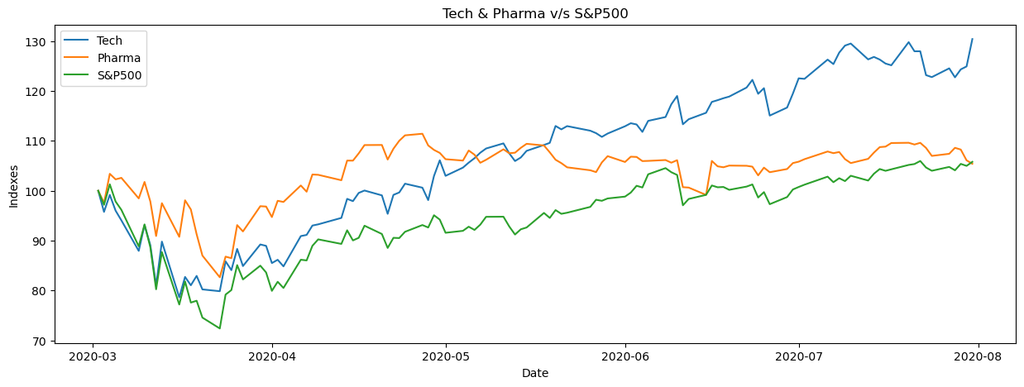

```python
# Create bins for the date values
lockdown1_techstock.index = pd.to_datetime(lockdown1_techstock.index)
date_bins = pd.date_range(start=lockdown1_techstock.index.min(), end=lockdown1_techstock.index.max())

# Assign bins to each date
lockdown1_techstock['date_bins'] = pd.cut(lockdown1_techstock.index, bins=date_bins)
plt.plot(lockdown1_techstock.index, lockdown1_techstock.TechReindex,label="Tech")
plt.plot(lockdown1_techstock.index, lockdown1_pharmastock.PharmaReindex,label="Pharma")
plt.plot(lockdown1_techstock.index, lockdown1_sp500['S&P500Reindex'],label="S&P500")

plt.xlabel("Date")
plt.ylabel("Indexes")
plt.title('Tech & Pharma v/s S&P500')
plt.legend()
plt.rcParams["figure.figsize"] = (15,5)
plt.show()
```

# Inference

1. Extended lockdowns provided people with more time, leading to increased engagement with technology applications.
2. The initial surge in pharmaceutical stocks was driven by optimistic expectations of a swift vaccine development.
3. As the realization of prolonged timelines for vaccine creation set in, the tech sector continued to thrive, while some investors shifted away from pharma, altering the market dynamics.

# Visualization 2: Telecom Index v/s Global Index

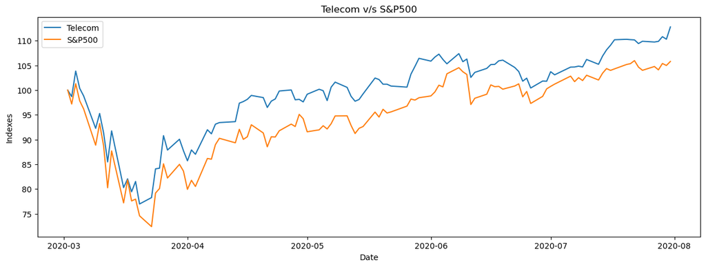

```python
# Create bins for the date values
lockdown1_telecomstock.index = pd.to_datetime(lockdown1_telecomstock.index)
date_bins = pd.date_range(start=lockdown1_telecomstock.index.min(), end=lockdown1_telecomstock.index.max())

# Assign bins to each date
lockdown1_telecomstock['date_bins'] = pd.cut(lockdown1_telecomstock.index, bins=date_bins)
plt.plot(lockdown1_telecomstock.index, lockdown1_telecomstock.TelecomReindex,label='Telecom')
plt.plot(lockdown1_techstock.index, lockdown1_sp500['S&P500Reindex'],label='S&P500')

plt.xlabel("Date")
plt.ylabel("Indexes")
plt.title('Telecom v/s S&P500')
plt.legend()
plt.rcParams["figure.figsize"] = (15,5)
plt.show()
```

# Visualization 3: FMCG Index v/s Global Index

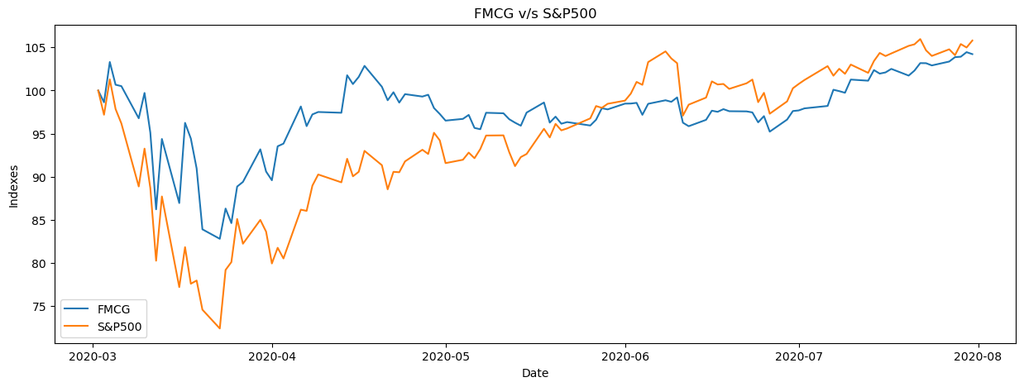

```python
# Create bins for the date values
lockdown1_fmcgstock.index = pd.to_datetime(lockdown1_fmcgstock.index)
date_bins = pd.date_range(start=lockdown1_fmcgstock.index.min(), end=lockdown1_fmcgstock.index.max())

# Assign bins to each date
lockdown1_fmcgstock['date_bins'] = pd.cut(lockdown1_fmcgstock.index, bins=date_bins)
plt.plot(lockdown1_fmcgstock.index, lockdown1_fmcgstock.FMCGReindex,label='FMCG')
plt.plot(lockdown1_techstock.index, lockdown1_sp500['S&P500Reindex'],label='S&P500')

plt.xlabel("Date")
plt.ylabel("Indexes")
plt.title('FMCG v/s S&P500')
plt.legend()
plt.rcParams["figure.figsize"] = (15,5)
plt.show()
```

# Conclusion:

We are still in process of doing our analysis, this is our progress so far-  
We were able to gather the stocks data from Yahoo and market website, clean the data and made it consisent. Further we preprocessed our data before starting our analysis, where we created indexes of each stock and then reindexed them to calculate the percent change in the stock price. Finally, we started our analysis on the COVID lockdown phase 1 effects on the stocks from which we got to know that the Tech and Telecom sector were the tailwind for the global economy and rest of them were kind of acting as taillwinds but then became headwinds.